# Lorentzian lineshape in Nuclear Magnetic Resonance

Fernaldo R. Winnerdy

## Nuclear Magnetic Resonance

Nuclear Magnetic Resonance **(NMR)** is a biophysical technique that is frequently used to determine the structure and interactions of biomolecules. Generally, each nucleus will generate a signal in a form of a Lorentzian peak. This Lorentzian peak carries the information of the corresponding nucleus based on its x-axis position as well as its linewidth.

- The position of the peak describes the electron shielding around the nucleus.
- The linewidth of the peak describes the relaxation time of the nucleus.

## Lorentzian Curve

A Lorentzian curve is a near-gaussian curve described by the following equation:

$$L(x) = \frac{\frac{1}{2}\Gamma}{(x - x_0)^2 + (\frac{1}{2} \Gamma)}$$

where $Gamma$ is the lineshape and $x_0$ is the central position.

A *normalized* Lorentzian curve has an additional factor of $1/\pi$ in front to control the area under the curve to be always equal to 1:

$$L(x) = \frac{1}{\pi} \frac{\frac{1}{2}\Gamma}{(x - x_0)^2 + (\frac{1}{2} \Gamma)}$$

## The applications

The concept of the application is a visualization on how the signal strength (amplitude) depends on the linewidth. Below are some demonstrations on the amplitude values ($L(x_0)$), given a series of linewidth values.

```r
linewidth <- c(1:5)
amplitude <- (1/pi)*(linewidth/2)/(linewidth/2)^2

cbind(linewidth, amplitude)
```

```
##      linewidth amplitude
## [1,]         1 0.6366198
## [2,]         2 0.3183099
## [3,]         3 0.2122066
## [4,]         4 0.1591549
## [5,]         5 0.1273240
```

The amplitude decreases with increasing linewidth

## Visualization

Below are two comparison plots on narrow linewidth and wide linewidth signals

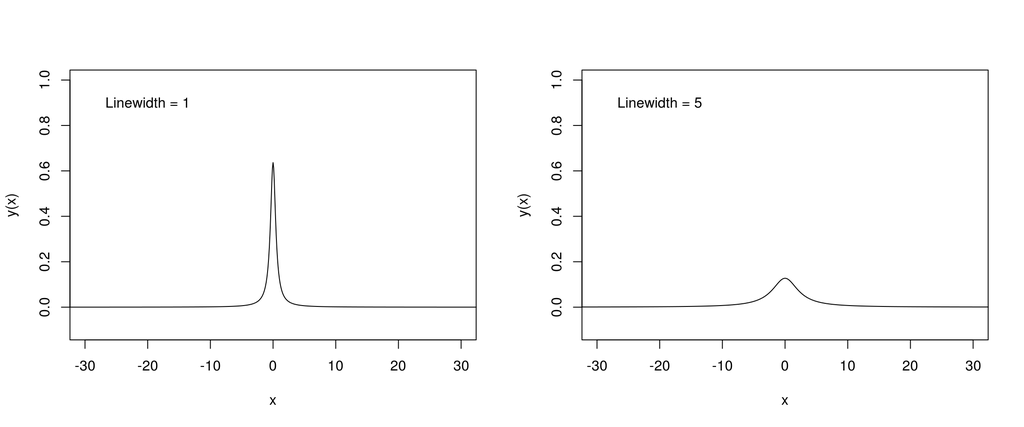